# DATA622 | Machine Learning and Big Data

Gabriella Martinez

5/14/2023

# Final Project

**Exploratory analysis and essay**

1. Choose a dataset. You get to decide which dataset you want to work on. The data set must be different from the ones used in previous homeworks You can work on a problem from your job, or something you are interested in. You may also obtain a dataset from sites such as Kaggle, Data.Gov, Census Bureau, USGS or other open data portals.
2. Select one of the methodologies studied in weeks 1-10, and another methodology from weeks 11-15 to apply in the new dataset selected.
3. To complete this task:
   1. Describe the problem you are trying to solve.
   2. Describe your datasets and what you did to prepare the data for analysis.
   3. Methodologies you used for analyzing the data
   4. What’s the purpose of the analysis performed
   5. Make your conclusions from your analysis. Please be sure to address the business impact (it could be of any domain) of your solution.

**Deliverable**

1. Your final presentation should incliude:
   1. The traditional R file or Python file and essay
   2. An Essay (minimum 500 word document) or Video (5 to 8 minutes recording). Include the execution and explanation of your code. The video can be recorded on any platform of your choice (Youtube, Free Cam).

Syringe Collection Efforts in the Bronx

[figure not shown]

Credit: [West/south BX community react: Syringe dropoff kiosks installed in parks](https://www.bxtimes.com/west-south-bx-community-react-syringe-dropoff-kiosks-installed-in-parks/)

```r
#Packages
library(readr)
library(tidyverse)
library(tidymodels)
library(psych)
library(caret)
library(rpart)
library(rpart.plot)
library(corrplot)
library(RColorBrewer)
library(labelled)
library(ggplot2)
library(ggforce)
library(pROC)
library(mlbench)
library(ModelMetrics)
library(randomForest)
library(e1071)
library(RSocrata)
library(Amelia)
library(kableExtra)
library(lubridate)
library(zoo)
library(neuralnet)
library(keras)
library(tensorflow)
library(stringi)
library(pls)
```

# Load Data

The Underlying Causes of death data was obtained from the [CDC Wonder database](https://wonder.cdc.gov/ucd-icd10.html)

The [Summary of Syringe Data in NYC Parks dataset](https://data.cityofnewyork.us/Public-Safety/Summary-of-Syringe-Data-in-NYC-Parks/t8xi-d5wb) and The [Parks Properties](https://data.cityofnewyork.us/Recreation/Parks-Properties/enfh-gkve) [Open NYC Data](https://opendata.cityofnewyork.us/) datasets used to gather data on the syringes collected and parks where syringes are collected.

```r
syr <- read.csv("https://raw.githubusercontent.com/gabbypaola/DATA622/main/Final/Summary_of_Syringe_Data_in_NYC_Parks.csv")
df_syr <- syr

pk <- read.csv("https://raw.githubusercontent.com/gabbypaola/DATA622/main/Final/Parks_Properties.csv")
df_pk <- pk

dth <- read_tsv("https://raw.githubusercontent.com/gabbypaola/DATA622/main/Final/CountyMonthYearRaceDeaths.txt", show_col_types = FALSE)
df_dth <- dth
```

# Exploratory Data Analysis

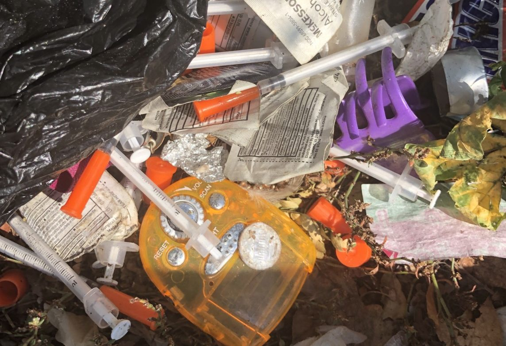

A pile of syringes found under a tree on a sidewalk on St. Anne’s Avenue. These were a few of 1,200 syringes and identifiable needle parts found by the Bronx Ink in the area surrounding the Hub at 149th Street and 3rd Avenue on September 10, 2019. Credit: [A Zone of Neglect](http://bronxink.org/2019/09/19/28351-a-zone-of-neglect/)

## Dimensions, Variable types, Labels, Levels, and Frequencies

### Summary of Syringe Data in NYC Parks

This dataset contains records of syringes collected, including how many, whether they are collected from the ground or a kiosk, and when they are collected. The Syringe Summary dataset contains records for syringes collected by both Parks staff as well as collection efforts by the [Washington Heights Corner Project](https://www.nycservice.org/organizations/index.php?org_id=1462) and [New York Harm Reduction Educators](https://nyhre.org/) nonprofit group. Each row one instance or one day’s total of syringes collected in a park from the ground or safe disposal kiosk.

From the below two functions, the dimensions of the dataset: 24651 rows, 23 columns. The variables read in do not contain any labels and as neither variable is a factor type, there are no factor levels to report. Additionally, the table contains 15 character type variables, 1 double variable, and 7 integer variables.

```r
glimpse(df_syr)
```

```
## Rows: 24,651
## Columns: 23
## $ response_id     <chr> "X-4143.0", "X-4141.0", "X-4370.0", "X-4369.0", "X-436~
## $ gispropnum      <chr> "", "", "", "", "", "", "", "", "", "", "", "", "", ""~
## $ omppropid       <chr> "", "", "", "", "", "", "", "", "", "", "", "", "", ""~
## $ collected_date  <chr> "11/01/2022 12:00:00 AM", "10/31/2022 12:00:00 AM", "1~
## $ time_of_day     <chr> "AM", "AM", "AM", "AM", "AM", "AM", "AM", "AM", "AM", ~
## $ year            <int> 2022, 2022, 2022, 2022, 2022, 2022, 2023, 2022, 2022, ~
## $ month           <int> 11, 10, 12, 12, 12, 12, 1, 5, 4, 6, 6, 6, 6, 6, 7, 7, ~
## $ month_text      <chr> "Nov", "Oct", "Dec", "Dec", "Dec", "Dec", "Jan", "May"~
## $ week            <int> 45, 45, 50, 50, 50, 49, 2, 19, 18, 25, 25, 24, 24, 24,~
## $ group           <chr> "Parks", "Parks", "Parks", "Parks", "Parks", "Parks", ~
## $ location        <chr> "", "", "", "", "", "", "", "", "", "", "", "", "", ""~
## $ ground_syringes <int> 86, 66, 12, 56, 32, 43, 53, 25, 15, 65, 70, 46, 100, 3~
## $ kiosk_syringes  <dbl> NA, NA, NA, NA, NA, NA, NA, NA, NA, NA, NA, NA, NA, NA~
## $ total_syringes  <int> 86, 66, 12, 56, 32, 43, 53, 25, 15, 65, 70, 46, 100, 3~
## $ kiosk_number    <int> NA, NA, NA, NA, NA, NA, NA, NA, NA, NA, NA, NA, NA, NA~
## $ kiosk_type      <chr> "", "", "", "", "", "", "", "", "", "", "", "", "", ""~
## $ precinct        <int> NA, NA, NA, NA, NA, NA, NA, NA, NA, NA, NA, NA, NA, NA~
## $ borough         <chr> "", "", "", "", "", "", "", "", "", "", "", "", "", ""~
## $ district        <chr> "X-07", "X-07", "X-07", "X-07", "X-07", "X-07", "X-07"~
## $ property_type   <chr> "", "", "", "", "", "", "", "", "", "", "", "", "", ""~
## $ kiosk_site      <chr> "false", "false", "false", "false", "false", "false", ~
## $ created_date    <chr> "2022-11-01 12:53:38.0000000", "2022-11-01 12:52:43.00~
## $ source          <chr> "M&O MS Forms", "M&O MS Forms", "M&O MS Forms", "M&O M~
```

```r
look_for(df_syr)
```

```
##  pos variable        label col_type values
##  1   response_id     —     chr
##  2   gispropnum      —     chr
##  3   omppropid       —     chr
##  4   collected_date  —     chr
##  5   time_of_day     —     chr
##  6   year            —     int
##  7   month           —     int
##  8   month_text      —     chr
##  9   week            —     int
##  10  group           —     chr
##  11  location        —     chr
##  12  ground_syringes —     int
##  13  kiosk_syringes  —     dbl
##  14  total_syringes  —     int
##  15  kiosk_number    —     int
##  16  kiosk_type      —     chr
##  17  precinct        —     int
##  18  borough         —     chr
##  19  district        —     chr
##  20  property_type   —     chr
##  21  kiosk_site      —     chr
##  22  created_date    —     chr
##  23  source          —     chr
```

```r
table(look_for(df_syr)$col_type)
```

```
##
## chr dbl int
##  15   1   7
```

Below are the counts of unique values for each variable. The purpose of this is to identify if there are any variables that may require a change of variable type from its originally loaded type.

```r
# Counts of unique values/levels for each variable
rapply(df_syr, function(x) length(unique(x)))
```

```
##     response_id      gispropnum       omppropid  collected_date     time_of_day
##           24651             286             411            1862               3
##            year           month      month_text            week           group
##               7              12              12              53               3
##        location ground_syringes  kiosk_syringes  total_syringes    kiosk_number
##             277             373             117             404              78
##      kiosk_type        precinct         borough        district   property_type
##               3              41               5              35               5
##      kiosk_site    created_date          source
##               3           20042               4
```

```r
# unique(df_syr$group)
# unique(df_syr$source)
```

After reviewing the variables, some are updated below. Not all variables will be updated as they will be dropped in the feature selection section.

```r
df_syr<- df_syr %>%
  mutate(collected_date =as.Date(str_sub(collected_date, start=1, end=10),format='%m/%d/%Y'),
         kiosk_site = as.logical(toupper(kiosk_site)),
         kiosk_syringes = as.integer(kiosk_syringes),
         kiosk_syringes = coalesce(kiosk_syringes, 0),
         ground_syringes = coalesce(ground_syringes, 0),
         total_syringes = ground_syringes + kiosk_syringes,
         # collection_type =
         #   case_when(ground_syringes == 0 & kiosk_syringes == 0    ~ "None",
         #             (ground_syringes >= 1 & kiosk_syringes == 0) ~ "Ground",
         #             (ground_syringes == 0 & kiosk_syringes >= 1) ~ "Kiosk",
         #             (ground_syringes >= 1 & kiosk_syringes >= 1) ~ "Ground & Kiosk"
         #             ),
         month_year = paste(month_text, year),
         # month = factor(month, levels= c(1,2,3,4,5,6,7,8,9,10,11,12)),
         # month_text = factor(month_text, levels= c("Jan", "Feb","Mar","Apr",
         #                                           "May","Jun","Jul","Aug",
         #                                           "Sep", "Oct", "Nov","Dec")),
         borough = case_when(substring(df_syr$district,1,1) == "M" ~ "Manhattan",
                             substring(df_syr$district,1,1)=="X" ~ "Bronx",
                             substring(df_syr$district,1,1) == "R" ~ "Staten Island",
                             substring(df_syr$district,1,1) == "Q" ~ "Queens",
                             substring(df_syr$district,1,1) == "B" ~ "Brooklyn"
                             )
         )

glimpse(df_syr)
```

```
## Rows: 24,651
## Columns: 24
## $ response_id     <chr> "X-4143.0", "X-4141.0", "X-4370.0", "X-4369.0", "X-436~
## $ gispropnum      <chr> "", "", "", "", "", "", "", "", "", "", "", "", "", ""~
## $ omppropid       <chr> "", "", "", "", "", "", "", "", "", "", "", "", "", ""~
## $ collected_date  <date> 2022-11-01, 2022-10-31, 2022-12-05, 2022-12-05, 2022-~
## $ time_of_day     <chr> "AM", "AM", "AM", "AM", "AM", "AM", "AM", "AM", "AM", ~
## $ year            <int> 2022, 2022, 2022, 2022, 2022, 2022, 2023, 2022, 2022, ~
## $ month           <int> 11, 10, 12, 12, 12, 12, 1, 5, 4, 6, 6, 6, 6, 6, 7, 7, ~
## $ month_text      <chr> "Nov", "Oct", "Dec", "Dec", "Dec", "Dec", "Jan", "May"~
## $ week            <int> 45, 45, 50, 50, 50, 49, 2, 19, 18, 25, 25, 24, 24, 24,~
## $ group           <chr> "Parks", "Parks", "Parks", "Parks", "Parks", "Parks", ~
## $ location        <chr> "", "", "", "", "", "", "", "", "", "", "", "", "", ""~
## $ ground_syringes <dbl> 86, 66, 12, 56, 32, 43, 53, 25, 15, 65, 70, 46, 100, 3~
## $ kiosk_syringes  <dbl> 0, 0, 0, 0, 0, 0, 0, 0, 0, 0, 0, 0, 0, 0, 0, 0, 0, 0, ~
## $ total_syringes  <dbl> 86, 66, 12, 56, 32, 43, 53, 25, 15, 65, 70, 46, 100, 3~
## $ kiosk_number    <int> NA, NA, NA, NA, NA, NA, NA, NA, NA, NA, NA, NA, NA, NA~
## $ kiosk_type      <chr> "", "", "", "", "", "", "", "", "", "", "", "", "", ""~
## $ precinct        <int> NA, NA, NA, NA, NA, NA, NA, NA, NA, NA, NA, NA, NA, NA~
## $ borough         <chr> "Bronx", "Bronx", "Bronx", "Bronx", "Bronx", "Bronx", ~
## $ district        <chr> "X-07", "X-07", "X-07", "X-07", "X-07", "X-07", "X-07"~
## $ property_type   <chr> "", "", "", "", "", "", "", "", "", "", "", "", "", ""~
## $ kiosk_site      <lgl> FALSE, FALSE, FALSE, FALSE, FALSE, FALSE, FALSE, FALSE~
## $ created_date    <chr> "2022-11-01 12:53:38.0000000", "2022-11-01 12:52:43.00~
## $ source          <chr> "M&O MS Forms", "M&O MS Forms", "M&O MS Forms", "M&O M~
## $ month_year      <chr> "Nov 2022", "Oct 2022", "Dec 2022", "Dec 2022", "Dec 2~
```

### Parks Properties

This dataset, provided by the Department of Parks and Recreation (DPR), identifies property managed partially or solely by NYC Parks. This data has been produced in whole or part using secondary data and is currently owned by the NYC Parks Open Data Team. Data accuracy is limited by the scale and accuracy of the original sources. Site-specific conditions should be field-verified.

Records are added as more land is designated under NYC Parks’ jurisdiction. Each record represents an acquisition.

```r
df_pk<- df_pk %>% select(c("GISPROPNUM","ACRES","JURISDICTION","COMMUNITYBOARD",
                           "COUNCILDISTRICT","SUBCATEGORY","TYPECATEGORY",
                           "WATERFRONT", "BOROUGH"))
glimpse(df_pk)
```

```
## Rows: 2,038
## Columns: 9
## $ GISPROPNUM      <chr> "Q084A", "Q498", "Q341D", "B510", "B502", "B462", "B42~
## $ ACRES           <dbl> 249.389, 9.375, 0.375, 0.230, 0.074, 0.275, 0.089, 0.1~
## $ JURISDICTION    <chr> "DPR/CDOT/SDOT", "DPR", "DPR", "DPR", "DPR", "DPR", "D~
## $ COMMUNITYBOARD  <dbl> 401403404406, 414, 402, 316, 303, 305, 301, 301, 413, ~
## $ COUNCILDISTRICT <dbl> 1921222429, 32, 26, 41, 36, 42, 34, 34, 31, 31, 33, 42~
## $ SUBCATEGORY     <chr> "EXWY", "", "Undeveloped", "Greenthumb", "Greenthumb",~
## $ TYPECATEGORY    <chr> "Parkway", "Undeveloped", "Strip", "Garden", "Garden",~
## $ WATERFRONT      <chr> "true", "true", "false", "false", "false", "false", "f~
## $ BOROUGH         <chr> "Q", "Q", "Q", "B", "B", "B", "B", "B", "Q", "Q", "B",~
```

```r
table(look_for(df_pk)$col_type)
```

```
##
## chr dbl
##   6   3
```

Below shows counts of unique values/levels for each variable and preliminary data cleaning is conducted.

```r
# df_pk<- df_pk %>% select(c("GISPROPNUM","ACRES","JURISDICTION","COMMUNITYBOARD",
#                            "COUNCILDISTRICT","SUBCATEGORY","TYPECATEGORY",
#                            "WATERFRONT"))

# Counts of unique values/levels for each variable
rapply(df_pk %>% keep(is.character), function(x) length(unique(x)))
```

```
##   GISPROPNUM JURISDICTION  SUBCATEGORY TYPECATEGORY   WATERFRONT      BOROUGH
##         2031           31           34           19            3            5
```

```r
#display top 10 levels and corresponding counts of selected variables
#df_pk %>% count(JURISDICTION) %>% arrange(-n) %>% head(10)

#first display numeric as non-scientific number, then convert to char, then trim whitespace
df_pk$COMMUNITYBOARD<-trimws(as.character(format(df_pk$COMMUNITYBOARD,scientific = FALSE)))
df_pk$COUNCILDISTRICT<-trimws(as.character(format(df_pk$COUNCILDISTRICT,scientific = FALSE)))

#split strings for community board and council district values, update decimal, and var type
df_pk<-df_pk %>%
  mutate(COMMUNITYBOARD = ifelse(nchar(df_pk$COMMUNITYBOARD)==3,
                                 df_pk$COMMUNITYBOARD,
                                 str_sub(gsub('(.{3})','\\1,',df_pk$COMMUNITYBOARD),end=-2)),
         COUNCILDISTRICT =  ifelse(nchar(df_pk$COUNCILDISTRICT)==2,
                                 df_pk$COUNCILDISTRICT,
                                 str_sub(gsub('(.{2})','\\1,',df_pk$COUNCILDISTRICT),end=-2)),
         ACRES = round(ACRES,2),
         WATERFRONT = as.logical(toupper(WATERFRONT)),
         BOROUGH = case_when(BOROUGH == "X" ~ "Bronx",
                             BOROUGH == "B" ~ "Brooklyn",
                             BOROUGH == "Q" ~ "Queens",
                             BOROUGH == "M" ~ "Manhattan",
                             BOROUGH == "R" ~ "Staten Island")
         )

#change column cases to lowercase
names(df_pk) <- tolower(names(df_pk))

#unique(df_pk$borough)
glimpse(df_pk)
```

```
## Rows: 2,038
## Columns: 9
## $ gispropnum      <chr> "Q084A", "Q498", "Q341D", "B510", "B502", "B462", "B42~
## $ acres           <dbl> 249.39, 9.38, 0.38, 0.23, 0.07, 0.28, 0.09, 0.12, 111.~
## $ jurisdiction    <chr> "DPR/CDOT/SDOT", "DPR", "DPR", "DPR", "DPR", "DPR", "D~
## $ communityboard  <chr> "401,403,404,406", "414", "402", "316", "303", "305", ~
## $ councildistrict <chr> "19,21,22,24,29", "32", "26", "41", "36", "42", "34", ~
## $ subcategory     <chr> "EXWY", "", "Undeveloped", "Greenthumb", "Greenthumb",~
## $ typecategory    <chr> "Parkway", "Undeveloped", "Strip", "Garden", "Garden",~
## $ waterfront      <lgl> TRUE, TRUE, FALSE, FALSE, FALSE, FALSE, FALSE, FALSE, ~
## $ borough         <chr> "Queens", "Queens", "Queens", "Brooklyn", "Brooklyn", ~
```

Next, the syringe collection data is merged with the parks data.

```r
df <- left_join(x=df_syr, y=df_pk, by="gispropnum", relationship = "many-to-many")

df <- df %>% select(-borough.x) %>%
  rename(borough= borough.y)

glimpse(df)
```

```
## Rows: 24,654
## Columns: 31
## $ response_id     <chr> "X-4143.0", "X-4141.0", "X-4370.0", "X-4369.0", "X-436~
## $ gispropnum      <chr> "", "", "", "", "", "", "", "", "", "", "", "", "", ""~
## $ omppropid       <chr> "", "", "", "", "", "", "", "", "", "", "", "", "", ""~
## $ collected_date  <date> 2022-11-01, 2022-10-31, 2022-12-05, 2022-12-05, 2022-~
## $ time_of_day     <chr> "AM", "AM", "AM", "AM", "AM", "AM", "AM", "AM", "AM", ~
## $ year            <int> 2022, 2022, 2022, 2022, 2022, 2022, 2023, 2022, 2022, ~
## $ month           <int> 11, 10, 12, 12, 12, 12, 1, 5, 4, 6, 6, 6, 6, 6, 7, 7, ~
## $ month_text      <chr> "Nov", "Oct", "Dec", "Dec", "Dec", "Dec", "Jan", "May"~
## $ week            <int> 45, 45, 50, 50, 50, 49, 2, 19, 18, 25, 25, 24, 24, 24,~
## $ group           <chr> "Parks", "Parks", "Parks", "Parks", "Parks", "Parks", ~
## $ location        <chr> "", "", "", "", "", "", "", "", "", "", "", "", "", ""~
## $ ground_syringes <dbl> 86, 66, 12, 56, 32, 43, 53, 25, 15, 65, 70, 46, 100, 3~
## $ kiosk_syringes  <dbl> 0, 0, 0, 0, 0, 0, 0, 0, 0, 0, 0, 0, 0, 0, 0, 0, 0, 0, ~
```

[output cut: 18 more lines]

### Underlying Cause of Death

The Underlying Cause of Death database contains mortality and population counts for all U.S. counties. Data are based on death certificates for U.S. residents. Each death certificate identifies a single underlying cause of death and demographic data. The number of deaths, crude death rates or age-adjusted death rates, and 95% confidence intervals and standard errors for death rates can be obtained by place of residence (total U.S., region, state and county), age group (single-year-of age, 5-year age groups, 10-year age groups and infant age groups), race, Hispanic ethnicity, gender, year, cause-of-death (4-digit ICD-10 code or group of codes), injury intent and injury mechanism, drug/alcohol induced causes and urbanization categories. Data are also available for place of death, month and week day of death, and whether an autopsy was performed.

*Note: Stratifying the data into additional groups like gender, race, age causes data loss due to suppression rules in place by the CDC for [Assurance of Confidentiality](https://wonder.cdc.gov/wonder/help/ucd.html#Assurance%20of%20Confidentiality:~:text=What%20are%20the%20Assurance%20of%20Confidentiality%20constraints%20for%20the%20data%3F) constraints. Statistics representing fewer than ten (one to nine) deaths or births are suppressed. Population figures are also suppressed when the population represents fewer than ten persons. This dataset is stratified by County, Month Year, Race, Drug/Alcohol Induced Cause of death.

The dataset has 12 columns and 593 rows where 10 variables are character type, and 2 variables are double type (decimals).

```r
glimpse(df_dth)
```

```
## Rows: 593
## Columns: 12
## $ Notes                             <chr> NA, NA, NA, NA, NA, NA, NA, NA, NA, ~
## $ County                            <chr> "Albany County, NY", "Bronx County, ~
## $ `County Code`                     <dbl> 36001, 36005, 36005, 36005, 36005, 3~
## $ Month                             <chr> "Apr., 2021", "Jan., 2018", "Jan., 2~
## $ `Month Code`                      <chr> "2021/04", "2018/01", "2018/01", "20~
## $ `Single Race 6`                   <chr> "White", "Black or African American"~
## $ `Single Race 6 Code`              <chr> "2106-3", "2054-5", "2106-3", "2106-~
## $ `Drug/Alcohol Induced Cause`      <chr> "Drug poisonings (overdose) Unintent~
## $ `Drug/Alcohol Induced Cause Code` <chr> "D1", "D1", "D1", "D1", "D1", "D1", ~
## $ Deaths                            <dbl> 10, 20, 22, 24, 13, 10, 22, 19, 17, ~
## $ Population                        <chr> "Not Applicable", "Not Applicable", ~
## $ `Crude Rate`                      <chr> "Not Applicable", "Not Applicable", ~
```

```r
look_for(df_dth)
```

```
##  pos variable                        label col_type values
##  1   Notes                           —     chr
##  2   County                          —     chr
##  3   County Code                     —     dbl
##  4   Month                           —     chr
##  5   Month Code                      —     chr
##  6   Single Race 6                   —     chr
##  7   Single Race 6 Code              —     chr
##  8   Drug/Alcohol Induced Cause      —     chr
##  9   Drug/Alcohol Induced Cause Code —     chr
##  10  Deaths                          —     dbl
##  11  Population                      —     chr
##  12  Crude Rate                      —     chr
```

```r
table(look_for(df_dth)$col_type)
```

```
##
## chr dbl
##  10   2
```

The Underlying Cause of Death dataset contains information for all counties in the state of New York for the years 2018-2021 and causes of deaths include “Drug poisonings (overdose) Unintentional (X40-X44)” and “Drug poisonings (overdose) Undetermined (Y10-Y14)”.

The scope of this project is limited to deaths by unintentional overdose for the NYC area, specifically the Bronx. The data will be filtered for the five boroughs for exploratory analysis and county names will be used to add the borough name equivalent.

After filtering for the five boroughs the causes of death remaining are narrowed down to Drug poisonings (overdose) Suicide (X60-X64), Drug poisonings (overdose) Unintentional (X40-X44), and All other drug-induced causes. The data will be filtered further to only include Drug poisonings (overdose) Unintentional (X40-X44).

```r
df_dth <-dth

df_dth <- df_dth %>%
  select(c("County","Month","Month Code", "Single Race 6","Deaths",
           "Drug/Alcohol Induced Cause")) %>%
  filter(County %in% c("Bronx County, NY","Kings County, NY", "New York County, NY",
                       "Queens County, NY", "Richmond County, NY"),
         `Drug/Alcohol Induced Cause` == "Drug poisonings (overdose) Unintentional (X40-X44)") %>%
  mutate(borough= case_when(County == "Bronx County, NY" ~ "Bronx",
                            County == "Kings County, NY" ~ "Brooklyn",
                            County == "New York County, NY" ~ "Manhattan",
                            County == "Queens County, NY" ~ "Queens",
                            County == "Richmond County, NY" ~ "Staten Island"),
         year = factor(as.integer(trimws(substr(`Month Code`, 1, 4))),
                       levels= c(2018,2019,2020,2021)),
         month = factor(as.integer(trimws(substr(`Month Code`, 6,7))),
                        levels= c(1,2,3,4,5,6,7,8,9,10,11,12)),
         month_year = ifelse(month == 5, gsub(",", "", Month),
                             gsub(".,", "", Month)
                             )
         ) %>%
  rename(deaths="Deaths", race = "Single Race 6", cause = "Drug/Alcohol Induced Cause")


df_od_dth <- df_dth %>%
  select(borough, month, year, month_year, deaths, race)
```

```r
df_od_dth %>%
  group_by(borough) %>%
  summarise(total_deaths=sum(deaths, na.rm = T)) %>%
  kable(booktabs=TRUE)  %>%
  kable_styling(font_size = 9, latex_options = "scale_down")
```

| borough | total_deaths |
| --- | --- |
| Bronx | 2058 |
| Brooklyn | 1476 |
| Manhattan | 1203 |
| Queens | 919 |
| Staten Island | 296 |

## Variable Dependencies and Definitions

Variable with dependency on two other variables in the dataset:  
`total_syringes` = `ground_syringes` + `kiosk_syringes`

Variables that are a subset of one other variable: `year`, `month`, `month_text`, `week`, `time_of_day`, `collected_date` are granular versions of the `created_date` variable

`group`: BBP stand for Bloodborne Pathogen crew, a Parks group specifically trained to handle waste that could spread blood bourne pathogens. CP stands for Washington Heights Corner Project, a harm reduction nonprofit. NYHRE stands for New York Harm Reduction Educators, a harm reduction nonprofit.

The [Summary of Syringe Data in NYC Parks dataset](https://data.cityofnewyork.us/Public-Safety/Summary-of-Syringe-Data-in-NYC-Parks/t8xi-d5wb) was collected from the [Open NYC Data](https://opendata.cityofnewyork.us/). The dataset has a [data dictionary](https://docs.google.com/spreadsheets/d/1VSUqd1peSc-4D2XnBZNiLdxa0Jg4z62D/edit#gid=1183788427) available for the variables which provides a description along with other relevant information for each variable.

The [Parks Properties](https://data.cityofnewyork.us/Recreation/Parks-Properties/enfh-gkve) is also an Open NYC Data dataset which was brought in to gather additional data on the parks where syringes are collected. The [data dictionary](https://docs.google.com/spreadsheets/d/1Q4DBWu7riNFxWvy1vnTJHoOI3r2L9oW6eCN56jCNyCw/edit#gid=0) for the Parks Properties dataset in addition to the [user guide](https://docs.google.com/document/d/1NExNJF5YKID04oOopi0fHainRuGG3Pz_jKSrMujPsPk/edit) are available. The user guide is particularly useful for the detailed descriptions of the `TYPECATEGORY` variable not directly available on the data dictionary.

## Missing Data

```r
map(df_syr, ~sum(is.na(.))) %>% head(15) %>% t() %>%
  kable(booktabs=TRUE)  %>%
  kable_styling(font_size = 9, latex_options = "scale_down")
```

| response_id | gispropnum | omppropid | collected_date | time_of_day | year | month | month_text | week | group | location | ground_syringes | kiosk_syringes | total_syringes | kiosk_number |
| --- | --- | --- | --- | --- | --- | --- | --- | --- | --- | --- | --- | --- | --- | --- |
| 0 | 0 | 0 | 0 | 0 | 0 | 0 | 0 | 0 | 0 | 0 | 0 | 0 | 0 | 18026 |

```r
map(df_syr, ~sum(is.na(.))) %>% tail(15) %>%t() %>%
  kable(booktabs=TRUE)  %>%
  kable_styling(font_size = 9, latex_options = "scale_down")
```

| group | location | ground_syringes | kiosk_syringes | total_syringes | kiosk_number | kiosk_type | precinct | borough | district | property_type | kiosk_site | created_date | source | month_year |
| --- | --- | --- | --- | --- | --- | --- | --- | --- | --- | --- | --- | --- | --- | --- |
| 0 | 0 | 0 | 0 | 0 | 18026 | 0 | 110 | 25 | 0 | 0 | 397 | 0 | 0 | 0 |

After reviewing the [notes](https://docs.google.com/spreadsheets/d/1VSUqd1peSc-4D2XnBZNiLdxa0Jg4z62D/edit#gid=1183788427) for `kiosk_syringes` and `ground_syringes`:

`ground_syringes`: NULL indicates that the group collecting syringes did not report a quantity of ground syringes collected for that visit, or did not collect syringes from the ground during that visit.

`kiosk_syringes`: NULL indicates that the group collecting syringes did not report a quantity of syringes removed from a kiosk for that visit (including zero), or did not empty kiosks during that visit.

Furthermore, after looking more into the data `kiosk_number` also has a large number of NAs, with 18,026 missing values. The notes for the variable are as follows:

`kiosk_number`: NULL indicates that a kiosk was not present at that location at that time, or the group collecting syringes did not service a kiosk during that visit.

With this information, some of the NAs in `kiosk_syringe` can have NAs replaced with 0s where a `kiosk_number` is present meaning a kiosk exists, however no syringes were collected that visit.

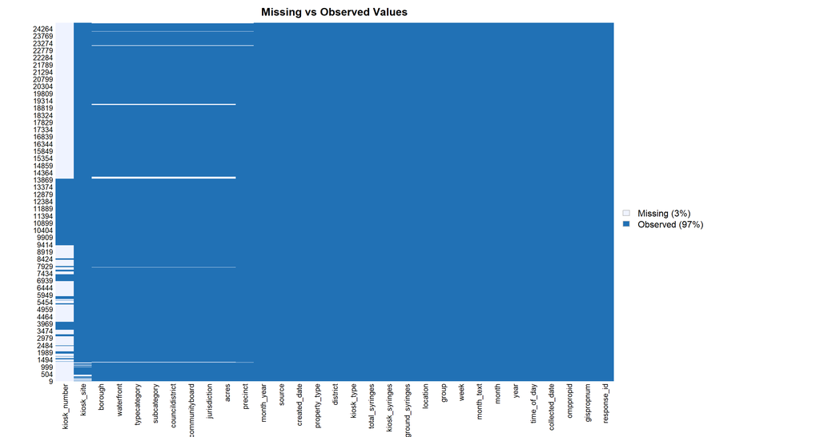

```r
missmap(df, main = "Missing vs Observed Values")
```

## Distributions

### Numeric Variables

From the describe() output for the dataset, it is noted that the numeric variables have wide ranges. This will be taken care of in the preprocessing stage by scaling the variables prior to running models. The five numeric variables in the dataset are all right skewed where acres and deaths are multimodal.

```r
#SYRINGE & PARK
df_n<- df %>%
  select(c("ground_syringes", "kiosk_syringes", "total_syringes","acres"))

#stats
describe(df_n) %>%
  select(c(-vars,-trimmed,-mad,-kurtosis))%>%
  kable(booktabs=TRUE)  %>%
  kable_styling(font_size = 9, latex_options = "scale_down")
```

|  | n | mean | sd | median | min | max | range | skew | se |
| --- | --- | --- | --- | --- | --- | --- | --- | --- | --- |
| ground_syringes | 24654 | 23.260972 | 77.30975 | 6.00 | 0.00 | 7000.00 | 7000.00 | 35.01315 | 0.4923689 |
| kiosk_syringes | 24654 | 5.248357 | 31.10157 | 0.00 | 0.00 | 1000.00 | 1000.00 | 12.60403 | 0.1980791 |
| total_syringes | 24654 | 28.509329 | 82.83798 | 9.00 | 0.00 | 7000.00 | 7000.00 | 29.20018 | 0.5275770 |
| acres | 24297 | 54.375686 | 81.56030 | 20.16 | 0.02 | 2771.75 | 2771.73 | 6.73846 | 0.5232418 |

```r
#DEATH
#stats
dth_n <- df_od_dth %>%
  select(deaths)

dth_n <- as.data.frame(dth_n)

describe(dth_n) %>%
  select(c(-vars,-trimmed,-mad,-kurtosis))%>%
  kable(booktabs=TRUE)  %>%
  kable_styling(font_size = 9, latex_options = "scale_down")
```

|  | n | mean | sd | median | min | max | range | skew | se |
| --- | --- | --- | --- | --- | --- | --- | --- | --- | --- |
| deaths | 314 | 18.95541 | 7.587061 | 18 | 10 | 53 | 43 | 1.278806 | 0.4281626 |

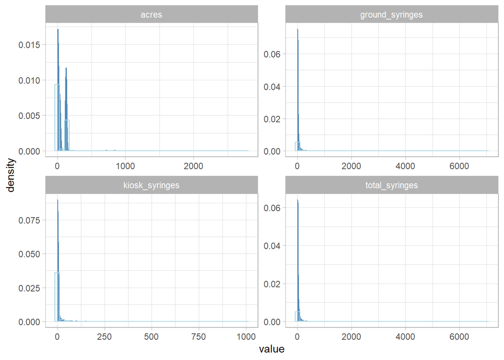

```r
#distributions
df_n %>%
  gather(variable, value, 1:4) %>%
  ggplot(aes(value)) +
    facet_wrap(~variable, scales = "free") +
    geom_density(fill = "steelblue", alpha=0.9, color="steelblue") +
    geom_histogram(aes(y=after_stat(density)), alpha=0.2, fill = "lightblue",
                   color="lightblue", position="identity",bins = 40) +
    theme_light()
```

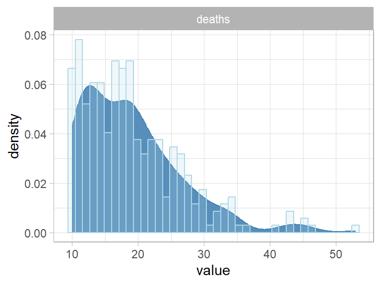

```r
#distribution histogram
dth_n %>%
  gather(variable, value, 1:1) %>%
  ggplot(aes(value)) +
    facet_wrap(~variable, scales = "free") +
    geom_density(fill = "steelblue", alpha=0.9, color="steelblue") +
    geom_histogram(aes(y=after_stat(density)), alpha=0.2, fill = "lightblue",
                   color="lightblue", position="identity",bins = 40) +
    theme_light()
```

### Categorical and Date-Time Variables

```r
df%>%
  rename(Borough = borough)%>%
  count(Borough, name="Total Collections") %>%
  arrange(-pick(starts_with("Total")))%>%
  kable(booktabs=TRUE)  %>%
  kable_styling(font_size = 9, latex_options = "scale_down")
```

| Borough | Total Collections |
| --- | --- |
| Bronx | 16085 |
| Manhattan | 8163 |
| NA | 357 |
| Staten Island | 39 |
| Queens | 10 |

```r
df%>%
  select(c(borough,total_syringes)) %>%
  group_by(borough) %>%
  summarise(total=sum(total_syringes, na.rm = T))%>%
  arrange(-total) %>%
  kable(booktabs=TRUE, col.names = c("Borough", "Total Syringes"))  %>%
  kable_styling(font_size = 9, latex_options = "scale_down")
```

| Borough | Total Syringes |
| --- | --- |
| Bronx | 420118 |
| Manhattan | 277088 |
| NA | 5444 |
| Staten Island | 190 |
| Queens | 29 |

The calculations for year-over-year values and year-over-year rates are as follows:

$YoY= \frac{total - lag(total)}{lag(total)}$ $YoY\_Rate =YoY\times100 :rounded\ to\ the\ hundreth$

where [`lag()`](https://www.rdocumentation.org/packages/stats/versions/3.6.2/topics/lag) is a time series shift from the `stats` package.

```r
df %>%
  filter(borough=="Bronx") %>%
  group_by(year) %>%
  summarise(total=sum(total_syringes, na.rm = T))%>%
  mutate(Change = ifelse(year %in% c(2017,2023), "-",total - lag(total)),
         YoY = ifelse(year %in% c(2017,2023), "-",
                      as.character(round((total - lag(total))/lag(total), 2))),
         YoY_Rate =  ifelse(year %in% c(2017,2023), "-",
                      as.character(round((total-lag(total))/lag(total)*100,2)))) %>%
  arrange(year) %>%
  kable(booktabs=TRUE, col.names = c("Year", "Total Syringes","Change",
                                     "Year over Year", "Year over Year Rate")) %>%
  kable_styling(font_size = 9, latex_options = "scale_down")
```

Change

Year over Year

Year over Year Rate

2017

3290

2018

92059

88769

26.98

2698.15

2019

68118

-23941

-0.26

-26.01

2020

60782

-7336

-0.11

-10.77

2021

76329

15547

0.26

25.58

2022

104570

28241

0.37

37

2023

14970

```r
df %>%
  filter(borough=="Bronx") %>%
  rename(Jurisdiction=jurisdiction) %>%
  count(Jurisdiction, name="Total Collections") %>%
  head(5)%>%
  arrange(-pick(starts_with("Total")))%>%
  kable(booktabs=TRUE)  %>%
  kable_styling(font_size = 9, latex_options = "scale_down")
```

| Jurisdiction | Total Collections |
| --- | --- |
| DPR | 13091 |
| DPR/DOE | 2989 |
| DPR/NYCHA | 5 |

Of the 14 different `typecategory` levels below are the top 5 with the highest amount of total syringes collected in the Bronx:

```r
# df %>%
#   filter(borough=="Bronx") %>%
#   rename(Typecategory=typecategory) %>%
#   count(Typecategory, name="Total Collections") %>%
#   head(5)%>%
#   arrange(-pick(starts_with("Total")))%>%
#   kable(booktabs=TRUE)  %>%
#   kable_styling(font_size = 9, latex_options = "scale_down")

df %>%
  filter(borough=="Bronx") %>%
  group_by(typecategory) %>%
  summarise(total=sum(total_syringes, na.rm = T)) %>%
  arrange(-total) %>%
  head(5) %>%
  kable(booktabs=TRUE, col.names = c("Type Category", "Total Syringes"))  %>%
  kable_styling(font_size = 9, latex_options = "scale_down")
```

| Type Category | Total Syringes |
| --- | --- |
| Community Park | 225672 |
| Neighborhood Park | 98325 |
| Jointly Operated Playground | 55963 |
| Triangle/Plaza | 17600 |
| Playground | 8640 |

Of the 13 different `subcategory` levels below are the top 5 with the highest amount of total syringes collected in the Bronx:

```r
# df %>%
#   filter(borough=="Bronx") %>%
#   rename(Subcategory=subcategory) %>%
#   count(Subcategory, name="Total Collections") %>%
#   head(5)%>%
#   arrange(-pick(starts_with("Total"))) %>%
#   kable(booktabs=TRUE)  %>%
#   kable_styling(font_size = 9, latex_options = "scale_down")

df %>%
  filter(borough=="Bronx") %>%
  group_by(subcategory) %>%
  summarise(total=sum(total_syringes, na.rm = T)) %>%
  arrange(-total) %>%
  head(5) %>%
  kable(booktabs=TRUE, col.names = c("Sub Category", "Total Syringes"))  %>%
  kable_styling(font_size = 9, latex_options = "scale_down")
```

| Sub Category | Total Syringes |
| --- | --- |
| Large Park | 289957 |
| JOP | 55963 |
| Neighborhood Park | 41826 |
| Sitting Area/Triangle/Mall | 18434 |
| Neighborhood Plgd | 13506 |

Below are total deaths due to overdose according to the CDC data for the 5 boroughs from 2018-2021.

```r
df_od_dth %>%
  group_by(borough,year) %>%
  summarise(total_deaths=sum(deaths, na.rm = T)) %>%
  kable(booktabs=TRUE)  %>%
  kable_styling(font_size = 9, latex_options = "scale_down")
```

| borough | year | total_deaths |
| --- | --- | --- |
| Bronx | 2018 | 354 |
| Bronx | 2019 | 376 |
| Bronx | 2020 | 530 |
| Bronx | 2021 | 798 |
| Brooklyn | 2018 | 210 |
| Brooklyn | 2019 | 262 |
| Brooklyn | 2020 | 420 |
| Brooklyn | 2021 | 584 |
| Manhattan | 2018 | 182 |
| Manhattan | 2019 | 233 |
| Manhattan | 2020 | 341 |
| Manhattan | 2021 | 447 |
| Queens | 2018 | 149 |
| Queens | 2019 | 148 |
| Queens | 2020 | 300 |
| Queens | 2021 | 322 |
| Staten Island | 2018 | 43 |
| Staten Island | 2019 | 55 |
| Staten Island | 2020 | 98 |
| Staten Island | 2021 | 100 |

With relation to deaths to overdoses, below are counts for the Bronx by race and year using the CDC data from 2018-2021.

```r
df_od_dth %>%
  filter(borough=="Bronx") %>%
  group_by(borough, race,year) %>%
  summarise(total_deaths=sum(deaths, na.rm = T)) %>%
  kable(booktabs=TRUE)  %>%
  kable_styling(font_size = 9, latex_options = "scale_down")
```

| borough | race | year | total_deaths |
| --- | --- | --- | --- |
| Bronx | Black or African American | 2018 | 120 |
| Bronx | Black or African American | 2019 | 137 |
| Bronx | Black or African American | 2020 | 195 |
| Bronx | Black or African American | 2021 | 306 |
| Bronx | White | 2018 | 234 |
| Bronx | White | 2019 | 239 |
| Bronx | White | 2020 | 335 |
| Bronx | White | 2021 | 492 |

# Preprocessing

[figure not shown]

Credit: [New Syringe Disposal Kiosks popping up at Bronx parks with highest number of used needles](https://www.ny1.com/nyc/all-boroughs/news/2018/06/08/syringe-disposal-kiosks-at-bronx-parks)

## Feature Selection

### Feature Selection from Syringe data

```r
#SYRINGE DATA
#filter syringes data, select columns, clean vars, drop nas
df_syr2 <- df_syr %>%
  filter(borough == "Bronx",
         year %in% c(2018,2019,2020,2021)) %>%
  select(c(gispropnum, borough, month, year, month_year, group, location, #collection_type,
           kiosk_site, kiosk_type, kiosk_site, kiosk_syringes, ground_syringes, total_syringes
           )) %>%
  mutate(kiosk_type = ifelse(kiosk_site==TRUE & is.na(kiosk_type), "Unspecified", kiosk_type),
         kiosk_site = ifelse(kiosk_syringes > 0, TRUE, kiosk_site),
         # year = factor(year, levels= c(2018,2019,2020,2021))
         ) %>%
  mutate_if(is.character, ~na_if(., '')) %>%
  na.omit()

#convert to yearmon type
df_syr2$month_year <- as.yearmon(df_syr2$month_year, "%b %Y")

map(df_syr2, ~sum(is.na(.))) %>% t()
```

```
##      gispropnum borough month year month_year group location kiosk_site
## [1,] 0          0       0     0    0          0     0        0
##      kiosk_type kiosk_syringes ground_syringes total_syringes
## [1,] 0          0              0               0
```

```r
glimpse(df_syr2)
```

```
## Rows: 3,833
## Columns: 12
## $ gispropnum      <chr> "X001", "X001", "X001", "X001", "X001", "X001", "X001"~
## $ borough         <chr> "Bronx", "Bronx", "Bronx", "Bronx", "Bronx", "Bronx", ~
## $ month           <int> 5, 6, 6, 7, 7, 7, 8, 8, 9, 9, 9, 9, 9, 11, 10, 10, 10,~
## $ year            <int> 2020, 2020, 2020, 2020, 2020, 2020, 2020, 2020, 2020, ~
## $ month_year      <yearmon> May 2020, Jun 2020, Jun 2020, Jul 2020, Jul 2020, ~
## $ group           <chr> "CP/NYHRE", "CP/NYHRE", "CP/NYHRE", "CP/NYHRE", "CP/NY~
## $ location        <chr> "Aqueduct Walk", "Aqueduct Walk", "Aqueduct Walk", "Aq~
## $ kiosk_site      <lgl> TRUE, TRUE, TRUE, TRUE, TRUE, TRUE, TRUE, TRUE, TRUE, ~
## $ kiosk_type      <chr> "Mailbox", "Mailbox", "Mailbox", "Mailbox", "Mailbox",~
## $ kiosk_syringes  <dbl> 0, 0, 0, 0, 0, 0, 0, 0, 0, 0, 0, 0, 0, 0, 0, 0, 1, 27,~
## $ ground_syringes <dbl> 0, 0, 0, 0, 0, 0, 0, 0, 0, 0, 0, 0, 0, 0, 0, 0, 0, 0, ~
## $ total_syringes  <dbl> 0, 0, 0, 0, 0, 0, 0, 0, 0, 0, 0, 0, 0, 0, 0, 0, 1, 27,~
```

### Feature Selection from Death data

```r
#DEATH DATA
#select columns
df_od_dth <- df_dth %>%
  select(borough, month, year, month_year, deaths, race)

#filter for Bronx, select columns
df_od_dth2 <- df_od_dth %>%
  filter(borough=="Bronx") %>%
  select(month_year, deaths, race)

#update to yearmon type
df_od_dth2$month_year <- as.yearmon(df_od_dth2$month_year, "%b %Y")

map(df_od_dth2, ~sum(is.na(.))) %>% t()
```

```
##      month_year deaths race
## [1,] 0          0      0
```

```r
glimpse(df_od_dth2)
```

```
## Rows: 89
## Columns: 3
## $ month_year <yearmon> Jan 2018, Jan 2018, Feb 2018, Mar 2018, Apr 2018, Apr 2~
## $ deaths     <dbl> 20, 22, 24, 13, 10, 22, 19, 17, 20, 12, 23, 12, 26, 11, 14,~
## $ race       <chr> "Black or African American", "White", "White", "White", "Bl~
```

### Feature Selection from Park data

```r
#PARK DATA
df_pk2 <- df_pk %>%
  filter(borough=="Bronx") %>%
  select(c(-borough, -councildistrict))

map(df_pk2, ~sum(is.na(.))) %>% t()
```

```
##      gispropnum acres jurisdiction communityboard subcategory typecategory
## [1,] 0          0     0            0              0           0
##      waterfront
## [1,] 0
```

```r
glimpse(df_pk2)
```

```
## Rows: 395
## Columns: 7
## $ gispropnum     <chr> "X139", "X033", "X183", "X050", "X025", "X060", "X329",~
## $ acres          <dbl> 0.31, 80.94, 1.05, 0.44, 1.11, 0.06, 0.11, 0.19, 0.40, ~
## $ jurisdiction   <chr> "DPR", "DPR", "DPR/DOE", "DPR", "DPR", "DPR", "DPR", "D~
## $ communityboard <chr> "201", "207,208", "210", "210", "209", "208", "206", "2~
## $ subcategory    <chr> "Sitting Area/Triangle/Mall", "Large Park", "JOP", "Par~
## $ typecategory   <chr> "Triangle/Plaza", "Parkway", "Jointly Operated Playgrou~
## $ waterfront     <lgl> FALSE, FALSE, FALSE, FALSE, FALSE, FALSE, FALSE, FALSE,~
```

### Merge Syringe, Death, and Park data

```r
#MERGE DATA
#merge syringe data with death data
syr_dth <- merge(x=df_syr2, y=df_od_dth2, by= "month_year", all=TRUE)

#merge syringe and death data with park data
syr_dth_pk <- merge(x=syr_dth , y= df_pk2, by="gispropnum", all=TRUE)
```

### Aggregation

```r
agg_df <- aggregate(cbind(kiosk_syringes, ground_syringes, total_syringes) ~
            month_year +  month + year + jurisdiction + communityboard +
              subcategory + typecategory + waterfront + acres +
              location + kiosk_type + kiosk_site + group +  race + deaths,
          data = syr_dth_pk,
          FUN = sum)
```

## Correlations

```r
num<- agg_df%>%
  select(deaths,total_syringes,kiosk_syringes,ground_syringes)

cor(num,method = "pearson", use = "complete.obs") %>%
  kable(booktabs=TRUE)  %>%
  kable_styling(font_size = 9, latex_options = "scale_down")
```

|  | deaths | total_syringes | kiosk_syringes | ground_syringes |
| --- | --- | --- | --- | --- |
| deaths | 1.0000000 | -0.0816434 | -0.0011793 | -0.1493645 |
| total_syringes | -0.0816434 | 1.0000000 | 0.8439738 | 0.6358421 |
| kiosk_syringes | -0.0011793 | 0.8439738 | 1.0000000 | 0.1226424 |
| ground_syringes | -0.1493645 | 0.6358421 | 0.1226424 | 1.0000000 |

## Feature Engineering

```r
agg_df <- agg_df %>%
  mutate(collection_type =
           case_when(ground_syringes == 0 & kiosk_syringes == 0 ~ "None",
                     (ground_syringes >= 1 & kiosk_syringes == 0) ~ "Ground",
                     (ground_syringes == 0 & kiosk_syringes >= 1) ~ "Kiosk",
                     (ground_syringes >= 1 & kiosk_syringes >= 1) ~ "Ground & Kiosk"
                     )
         ) %>%
  mutate_if(is.character, ~na_if(., ''))

map(agg_df, ~sum(is.na(.))) %>% t()
```

```
##      month_year month year jurisdiction communityboard subcategory typecategory
## [1,] 0          0     0    0            0              0           0
##      waterfront acres location kiosk_type kiosk_site group race deaths
## [1,] 0          0     0        0          0          0     0    0
##      kiosk_syringes ground_syringes total_syringes collection_type
## [1,] 0              0               0              0
```

```r
glimpse(agg_df)
```

```
## Rows: 1,204
## Columns: 19
## $ month_year      <yearmon> Oct 2018, Feb 2020, Oct 2018, Nov 2018, Feb 2020, ~
## $ month           <int> 10, 2, 10, 11, 2, 10, 11, 2, 10, 11, 2, 2, 10, 11, 2, ~
## $ year            <int> 2018, 2020, 2018, 2018, 2020, 2018, 2018, 2020, 2018, ~
## $ jurisdiction    <chr> "DPR", "DPR", "DPR", "DPR", "DPR", "DPR", "DPR", "DPR"~
## $ communityboard  <chr> "201", "201", "202", "202", "202", "204", "204", "204"~
## $ subcategory     <chr> "Sitting Area/Triangle/Mall", "Large Park", "Large Par~
## $ typecategory    <chr> "Triangle/Plaza", "Community Park", "Recreation Field/~
## $ waterfront      <lgl> FALSE, FALSE, FALSE, FALSE, FALSE, FALSE, FALSE, FALSE~
## $ acres           <dbl> 0.22, 35.31, 7.74, 7.74, 7.74, 38.54, 38.54, 38.54, 0.~
## $ location        <chr> "Ryan Triangle", "St. Mary's Park", "Bill Rainey Park"~
## $ kiosk_type      <chr> "Mailbox", "Mailbox", "Bathroom", "Bathroom", "Bathroo~
## $ kiosk_site      <lgl> FALSE, FALSE, TRUE, TRUE, TRUE, TRUE, TRUE, TRUE, TRUE~
## $ group           <chr> "CP/NYHRE", "CP/NYHRE", "CP/NYHRE", "CP/NYHRE", "CP/NY~
## $ race            <chr> "Black or African American", "Black or African America~
## $ deaths          <dbl> 10, 10, 10, 10, 10, 10, 10, 10, 10, 10, 10, 10, 10, 10~
## $ kiosk_syringes  <dbl> 0, 0, 20, 53, 63, 0, 0, 0, 193, 50, 167, 6, 0, 0, 6, 3~
## $ ground_syringes <dbl> 0, 0, 0, 25, 0, 0, 0, 0, 20, 22, 0, 0, 0, 0, 0, 0, 60,~
## $ total_syringes  <dbl> 0, 0, 20, 78, 63, 0, 0, 0, 213, 72, 167, 6, 0, 0, 6, 3~
## $ collection_type <chr> "None", "None", "Kiosk", "Ground & Kiosk", "Kiosk", "N~
```

## Scaling

Next, the data is scaled in preparation for modelling. When variables are measured at different scales, they often do not contribute equally to the analysis. For example, if the values of one variable range from 0 to 100,000 and the values of another variable range from 0 to 100, the variable with the larger range will be given a larger weight in the analysis. By scaling the variables, we can be sure that each variable contributes equally to the analysis and reduce the variance effect.

```r
#apply preprocessing and generate transformed values
agg_df_norm <- predict(preProcess(agg_df, method=c("center", "scale")),agg_df)

#stats
agg_df_norm %>%
  keep(is.numeric) %>%
  describe(fast=TRUE) %>%
  select(-c(vars,n)) %>%
  kable(booktabs=TRUE)  %>%
  kable_styling(font_size = 9, latex_options = "scale_down")
```

|  | mean | sd | min | max | range | se |
| --- | --- | --- | --- | --- | --- | --- |
| month | 0 | 1 | -1.8651179 | 1.469334 | 3.334452 | 0.0288195 |
| year | 0 | 1 | -1.5358042 | 1.388458 | 2.924262 | 0.0288195 |
| acres | 0 | 1 | -0.6639087 | 3.111105 | 3.775014 | 0.0288195 |
| deaths | 0 | 1 | -1.3633977 | 3.257908 | 4.621306 | 0.0288195 |
| kiosk_syringes | 0 | 1 | -0.3240046 | 10.843876 | 11.167881 | 0.0288195 |
| ground_syringes | 0 | 1 | -0.2201811 | 12.903482 | 13.123663 | 0.0288195 |
| total_syringes | 0 | 1 | -0.3709751 | 8.314174 | 8.685149 | 0.0288195 |

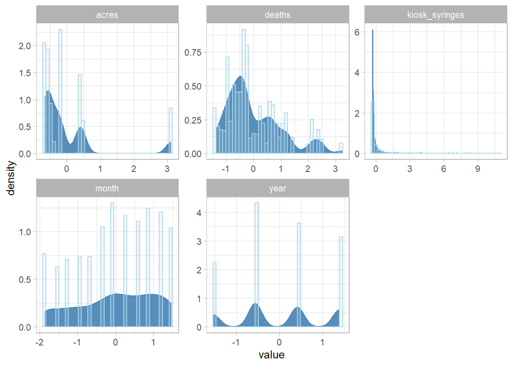

```r
#distribution
agg_df_norm %>%
  keep(is.numeric) %>%
  gather(variable, value, 1:5) %>%
  ggplot(aes(value)) +
    facet_wrap(~variable, scales = "free") +
    geom_density(fill = "steelblue", alpha=0.9, color="steelblue") +
    geom_histogram(aes(y=after_stat(density)), alpha=0.2, fill = "lightblue",
                   color="lightblue", position="identity", bins = 40) +
    theme_light()
```

# Models

### Tuned Random Forest Regression

### Predicting `deaths`

```
## mtry = 5  OOB error = 0.6783597
## Searching left ...
## mtry = 3     OOB error = 0.6264113
## 0.07657941 0.01
## mtry = 2     OOB error = 0.6435522
## -0.02736354 0.01
## Searching right ...
## mtry = 10    OOB error = 0.7370043
## -0.1765502 0.01
```

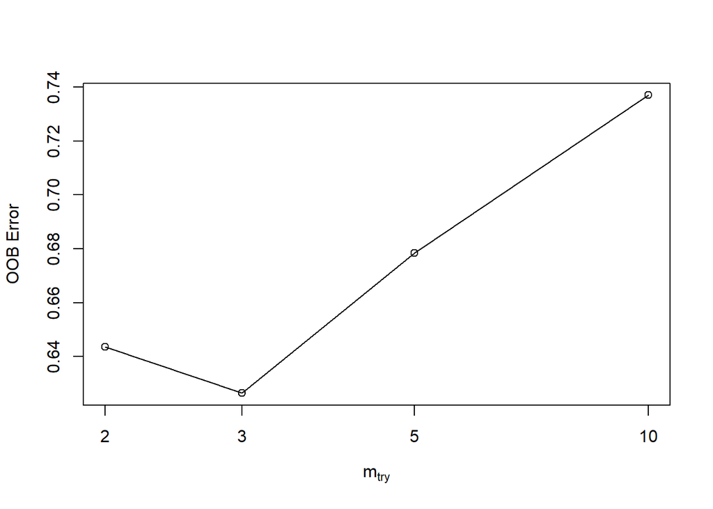

```r
#for reproducibility
set.seed(917)

agg_df_norm1 <- agg_df_norm %>%
  select(-c(month,year, month_year))
#(select(-c(month,year))

#split
training.samples <- agg_df_norm1$deaths %>%
  createDataPartition(p = 0.8, list = FALSE)

train  <- agg_df_norm1[training.samples, ]
test <- agg_df_norm1[-training.samples, ]

train1 <- train %>%
  select(-deaths)

bestmtry <- tuneRF(train1,train$deaths, stepFactor = 2, improve = 0.01,
                   trace=T, plot= T, doBest=TRUE, importance=TRUE)
```

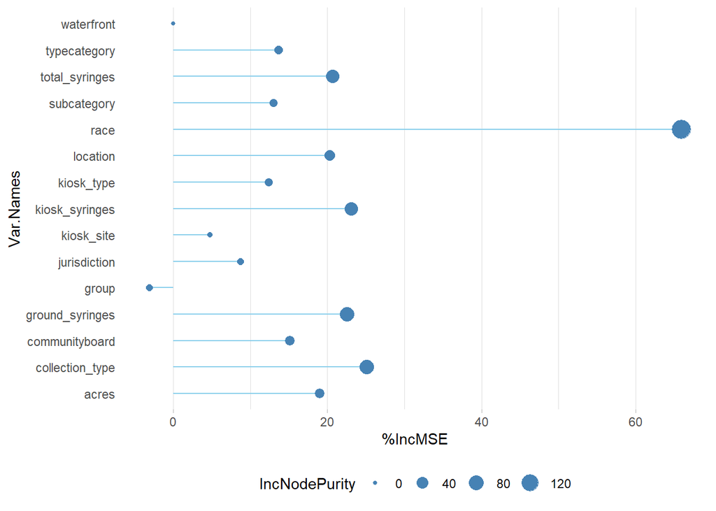

```r
#bestmtry

# Get variable importance from the model fit
ImpData <- as.data.frame(importance(bestmtry))
ImpData$Var.Names <- row.names(ImpData)

ggplot(ImpData, aes(x=Var.Names, y=`%IncMSE`)) +
  geom_segment( aes(x=Var.Names, xend=Var.Names, y=0, yend=`%IncMSE`), color="skyblue") +
  geom_point(aes(size = IncNodePurity), color="steelblue", alpha=1) +
  theme_light() +
  coord_flip() +
  theme(
    legend.position="bottom",
    panel.grid.major.y = element_blank(),
    panel.border = element_blank(),
    axis.ticks.y = element_blank()
  )
```

```r
#PREDICTIONS
trf_pred <- predict(bestmtry, newdata = test) %>%
  bind_cols(test)

trf_pred$...1 <- as.numeric(trf_pred$...1)
```

#### Performance

```r
a <- data.frame(Model = "Tuned Random Forest: deaths",
#mean absolute error
MAE = mae(trf_pred$deaths, trf_pred$...1),
#rmse Root Mean Squared Error
RMSE = rmse(trf_pred$deaths, trf_pred$...1)
#r squared
#R2 = R2(trf_pred$deaths, trf_pred$...1)
)
a
```

```
##                         Model       MAE      RMSE
## 1 Tuned Random Forest: deaths 0.6051472 0.7712956
```

```r
cor(trf_pred$deaths, trf_pred$...1)^2
```

```
## [1] 0.4325396
```

### Predicting `total_syringes`

```
## mtry = 5  OOB error = 0.0909651
## Searching left ...
## mtry = 3     OOB error = 0.1194968
## -0.3136556 0.01
## Searching right ...
## mtry = 10    OOB error = 0.03018307
## 0.6681906 0.01
## mtry = 16    OOB error = 0.01833298
## 0.3926072 0.01
```

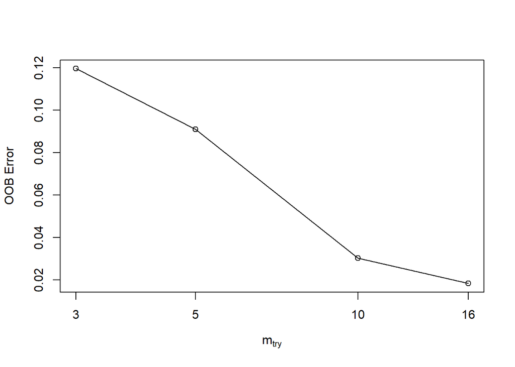

```r
#for reproducibility
set.seed(917)

agg_df_norm1 <- agg_df_norm %>%
  select(-c(month,year))

#split
training.samples <- agg_df_norm1$total_syringes %>%
  createDataPartition(p = 0.8, list = FALSE)

train  <- agg_df_norm1[training.samples, ]
test <- agg_df_norm1[-training.samples, ]

train1 <- train %>%
  select(-total_syringes)

bestmtry <- tuneRF(train1,train$total_syringes, stepFactor = 2, improve = 0.01,
                   trace=T, plot= T, doBest=TRUE, importance=TRUE)
```

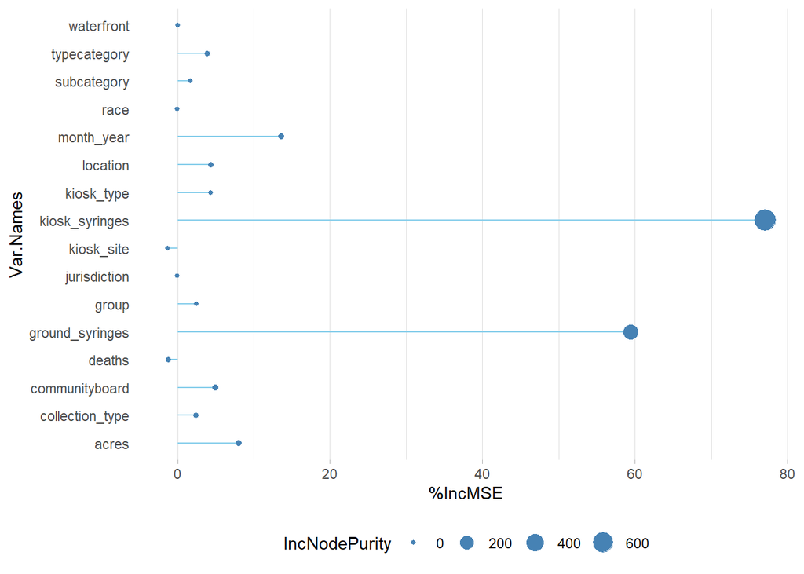

```r
#bestmtry

# Get variable importance from the model fit
ImpData <- as.data.frame(importance(bestmtry))
ImpData$Var.Names <- row.names(ImpData)

ggplot(ImpData, aes(x=Var.Names, y=`%IncMSE`)) +
  geom_segment( aes(x=Var.Names, xend=Var.Names, y=0, yend=`%IncMSE`), color="skyblue") +
  geom_point(aes(size = IncNodePurity), color="steelblue", alpha=1) +
  theme_light() +
  coord_flip() +
  theme(
    legend.position="bottom",
    panel.grid.major.y = element_blank(),
    panel.border = element_blank(),
    axis.ticks.y = element_blank()
  )
```

```r
#PREDICTIONS
trf_pred <- predict(bestmtry, newdata = test) %>%
  bind_cols(test)

trf_pred$...1 <- as.numeric(trf_pred$...1)
```

#### Performance

```r
b <- data.frame(Model = "Tuned Random Forest: total_syringes",
#mean absolute error
MAE = mae(trf_pred$total_syringes, trf_pred$...1),
#rmse Root Mean Squared Error
RMSE = rmse(trf_pred$total_syringes, trf_pred$...1)
#r squared
#R2 = R2(trf_pred$total_syringes, trf_pred$...1)
)

b
```

```
##                                 Model        MAE       RMSE
## 1 Tuned Random Forest: total_syringes 0.01556374 0.06937625
```

```r
cor(trf_pred$deaths, trf_pred$...1)^2
```

```
## [1] 0.0001848146
```